# Week 06: R for Data Analytics (Data Screening Part 1)

Ziyuan Huang

Last Updated: December 18, 2025

# Introduction

## 1. Overview

This Week 06 tutorial builds on our previous data analytics foundations and focuses on the critical first step of any analysis: **Data Screening**. Before running statistical models, we must ensure our data is clean, accurate, and meets necessary assumptions. This tutorial upgrades the lecture concepts from `06_datascreen_1.rmd` into hands-on, code-first workflows:

- **Accuracy Checks**: Identifying and fixing typos, out-of-range values, and coding errors.
- **Missing Data**: Understanding types of missingness (MCAR, MNAR) and handling them appropriately (deletion vs. imputation).
- **Outlier Detection**: Using univariate (Z-scores) and multivariate (Mahalanobis distance) methods.
- **Assumptions**: A brief introduction to what we prepare for (Normality, Linearity, etc.).

> **Reference:** This tutorial draws heavily from Field, Miles, and Field [1], *Discovering Statistics Using R*, particularly the chapters on data screening and cleaning, with IEEE-style citations throughout.

> **Upgrade note:** This hands-on tutorial extends the Week 06 lecture slides in `06_datascreen_1.rmd` with code-first workflows, beginner-friendly explanations, and theoretical grounding from Field et al. [1].

### For Beginners: Quick Start

- **How to run code:**
  - RStudio: place cursor in a chunk, press Ctrl+Enter (Cmd+Enter on Mac) to run; use Knit to render the full document.
  - VS Code: highlight lines and press Ctrl+Enter, or click the Run button above a chunk.
- **Installing packages:** if you see “there is no package called ‘X’”, run `install.packages("X")` once, then `library(X)`.
- **If stuck:** restart R (RStudio: Session → Restart R), then re-run chunks from the top (setup first).
- **Reading errors:** focus on the last lines of the message; they usually state the actual problem (e.g., object not found, package missing, misspelled column).

## 2. Learning Objectives

By the end of this tutorial, you will be able to:

1. Perform **accuracy checks** on categorical and continuous variables.
2. Diagnose types of **missing data** (MCAR vs. MNAR).
3. Implement strategies for **handling missing data**, including listwise deletion and multiple imputation with `mice`.
4. Detect and handle **univariate outliers** using Z-scores (cutoff $\pm 3.29$).
5. Detect and handle **multivariate outliers** using Mahalanobis distance.

## 3. Required Packages

```r
# Install if needed
# install.packages(c("tidyverse", "rio", "mice", "VIM", "knitr", "kableExtra", "ggplot2", "gridExtra"))

library(tidyverse)
library(ggplot2)  # For data visualization
library(gridExtra) # For arranging multiple plots
library(rio)      # For data import
library(mice)     # For multiple imputation
library(VIM)      # For visualizing missing data
library(knitr)
library(kableExtra)

cat("\n=== REPRODUCIBLE SEED INFORMATION ===")
```

```
##
## === REPRODUCIBLE SEED INFORMATION ===
```

```r
cat("\nGenerator Name: Week06 Data Screening - ANLY500")
```

```
##
## Generator Name: Week06 Data Screening - ANLY500
```

```r
cat("\nMD5 Hash:", gen$get_hash())
```

```
##
## MD5 Hash: 4476fe6d5a95542e0ac57b95797b6709
```

```r
cat("\nAvailable Seeds:", paste(seeds[1:5], collapse = ", "), "...\n\n")
```

```
##
## Available Seeds: -803686227, -78650771, -915116207, -338502455, 574023479 ...
```

# Part 1: Data Screening Principles

## 1.1 What is Data Screening?

Data screening is the process of inspecting a dataset for errors, missing values, and outliers before analysis. As Field et al. note, screening is crucial because issues like outliers can “bias the mean and inflate the standard deviation” [1], and missing data can arise from various sources (e.g., participants accidentally missing questions) [1]. Field explicitly refers to Tabachnick and Fidell as the “definitive guide to screening data” [1].

## 1.2 The “Garbage In, Garbage Out” Rule

Data screening is a key facet of any analysis. If the data is incorrect, the output will be useless. Screening ensures results are interpretable and valid. Our checks should always include:

1. **Accuracy**: Is the data correct? (e.g., “Age” shouldn’t be 200).
2. **Missing Data**: Is the data complete? (e.g., Did someone skip questions?).
3. **Outliers**: Are there extreme values? (e.g., A millionaire in a study of student income).
4. **Assumptions**: Does the data fit the rules of our statistical test? (e.g., Is it a bell curve?).

### An Important Note on Significance

Normally, our $\alpha$ value is set to 0.05 (Type 1 Error), meaning we use $p < .05$ as a criterion for statistical significance. However, **in data screening, we want to use a stricter criterion** to avoid over-cleaning or incorrectly flagging data. Therefore, we use **$p < .001$** to denote problematic issues [1].

## 1.3 The Order of Operations

We follow this specific order because each step can affect the next:

1. **Accuracy Check**: If you correct errors, they may become missing data points.
2. **Missing Data Check**: If you replace missing data, they may become outliers.
3. **Outliers Check**: If you exclude outliers, this may change assumption interpretations (e.g., normality).
4. **Assumptions**: Finally, check assumptions for the specific analysis to be performed.

# Part 2: Accuracy Checks

We will use a dataset that examines the resiliency (RS columns) of teenagers after a natural disaster. While we haven’t covered specific analyses yet, we can screen this data overall.

```r
# Import the dataset
# Note: Ensure "data/data_screening.csv" exists in your working directory or adjust the path
# If the file is not available, we will simulate a similar structure for this tutorial
if(file.exists("data/data_screening.csv")) {
  master <- import("data/data_screening.csv")
} else {
  # Simulation for tutorial purposes if file is missing
  set.seed(seeds[2])
  n <- 100
  master <- data.frame(
    Sex = sample(c(1, 2, 3), n, replace = TRUE, prob = c(0.45, 0.45, 0.1)), # 3 is typo
    SES = sample(c(1, 2, 3), n, replace = TRUE),
    Grade = sample(8:14, n, replace = TRUE), # >12 is typo
    Absences = sample(0:20, n, replace = TRUE), # >15 is typo
    RS1 = sample(1:7, n, replace = TRUE),
    RS2 = sample(1:7, n, replace = TRUE),
    RS3 = sample(c(1:7, 99), n, replace = TRUE, prob = c(rep(0.14, 7), 0.02)) # 99 is outlier/typo
  )
  # Introduce some missingness
  master[sample(1:n, 10), "RS1"] <- NA
  master[sample(1:n, 5), "SES"] <- NA
}

str(master)
```

```
## 'data.frame':    137 obs. of  20 variables:
##  $ Sex     : int  1 1 1 1 1 1 1 1 1 1 ...
##  $ Age     : int  17 16 13 15 16 15 12 14 13 18 ...
##  $ SES     : int  2 3 2 3 2 3 3 3 1 3 ...
##  $ Grade   : int  11 7 5 6 11 7 4 6 4 9 ...
##  $ Absences: int  2 2 2 2 6 2 1 2 2 5 ...
##  $ RS1     : int  6 7 5 5 7 7 1 2 6 7 ...
##  $ RS2     : int  4 1 NA 5 4 7 6 3 6 6 ...
##  $ RS3     : int  2 1 5 5 4 7 NA 2 7 5 ...
##  $ RS4     : int  2 5 7 7 7 7 1 3 6 NA ...
##  $ RS5     : int  4 7 4 5 4 7 4 2 1 6 ...
##  $ RS6     : int  7 7 6 6 4 7 7 3 4 6 ...
##  $ RS7     : int  7 7 7 5 7 7 7 3 6 10 ...
##  $ RS8     : int  4 7 6 7 7 7 NA 3 6 7 ...
##  $ RS9     : int  5 4 6 6 4 7 NA 2 2 7 ...
##  $ RS10    : int  7 7 7 7 7 7 4 2 5 7 ...
##  $ RS11    : int  4 1 NA 6 7 7 3 3 6 5 ...
##  $ RS12    : int  7 7 5 6 4 7 7 3 6 6 ...
##  $ RS13    : int  4 4 7 6 7 7 7 2 6 6 ...
##  $ RS14    : int  7 7 6 6 4 7 7 3 2 6 ...
##  $ Health  : int  6 6 2 2 6 4 3 6 1 5 ...
```

## 2.1 Categorical Variables

We need to check for factor variables incorrectly imported as numbers and out-of-range values. Let’s check `Sex` and `SES`.

### Visualizing the Problem

Before fixing, let’s visualize the `Sex` variable to see the error. We expect only two categories (e.g., 1 and 2), but a third bar might appear.

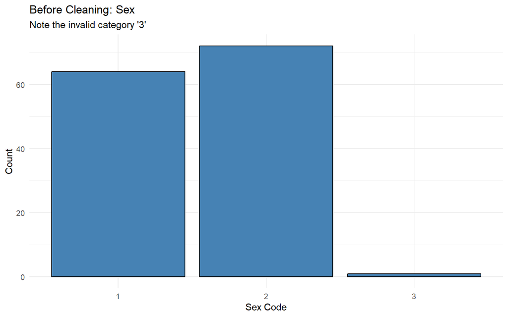

```r
p1 <- ggplot(master, aes(x = factor(Sex))) +
  geom_bar(fill = "steelblue", color = "black") +
  labs(title = "Before Cleaning: Sex",
       subtitle = "Note the invalid category '3'",
       x = "Sex Code",
       y = "Count") +
  theme_minimal()

p1
```

**Interpretation:** You can clearly see a bar for “3”. If our codebook says 1=Women and 2=Men, then “3” is a typo! This visual confirmation is faster than reading raw tables.

### Checking Tables

```r
notypos <- master # Create a copy to update
apply(notypos[ , c("Sex", "SES")], 2, table)
```

```
##   Sex SES
## 1  64   9
## 2  72  56
## 3   1  72
```

**Explanation:** - `apply(X, 2, table)`: This function takes our data (`X`), looks at columns (`2`), and runs the `table()` function on each one. - It’s a quick way to get counts for multiple columns at once.

### Fixing the Issue

We can fix this by using `factor()` and excluding the bad label. Values not listed in `levels` will automatically become `NA`.

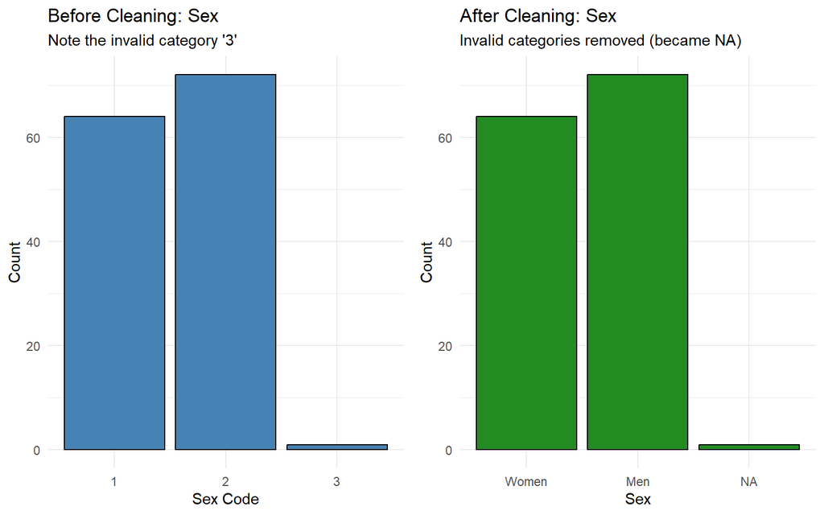

```r
## Fix categorical labels and drop typos
notypos$Sex <- factor(notypos$Sex,
                     levels = c(1,2), # We intentionally omit 3
                     labels = c("Women", "Men"))

notypos$SES <- factor(notypos$SES,
                     levels = c(1,2, 3),
                     labels = c("Low", "Medium", "High"))

# Let's verify with a plot
p2 <- ggplot(notypos, aes(x = Sex)) +
  geom_bar(fill = "forestgreen", color = "black") +
  labs(title = "After Cleaning: Sex",
       subtitle = "Invalid categories removed (became NA)",
       x = "Sex",
       y = "Count") +
  theme_minimal()

grid.arrange(p1, p2, ncol = 2)
```

**Visual Check:** The “Before” plot shows the error (3). The “After” plot shows only valid categories (Women, Men). The typos didn’t disappear; they became `NA` (missing values), which we will deal with later.